# test8

## Ensemble Learning

```python
from sklearn.datasets import make_classification
from sklearn.model_selection import GridSearchCV
import nose.tools as test_# For testing
import numpy as np
from sklearn.svm import SVC
from sklearn.metrics import accuracy_score
from sklearn.model_selection import train_test_split
```

```python
# Useful in beautifying numpy arrays.
from IPython.display import HTML, display
import tabulate
def pp(a, show_head=True):
    '''
    args: show_head -> if True print only first 5 rows.
    return: None
    '''
    if a.ndim < 2:
        a = [a]
    if show_head:
        display(HTML(tabulate.tabulate(a[:5], tablefmt='html')))
        return
    display(HTML(tabulate.tabulate(a, tablefmt='html')))
```

In this test, we'll use SVC, Bagging (voting, stacking etc) and Boosting and compare their performaces. To this end, let's use a difficult to learn dataset with 16 classses and 7 features (5 informative and 2 redundant).

### Question 1

`3 Points`

Generate a dataset using [make_classification](https://scikit-learn.org/stable/modules/generated/sklearn.datasets.make_classification.html) given a number of samples to generate, number of classes and number of features.

```python
def generate_dataset(n_samples_, n_classes_, n_features_, \
                           n_informative_, n_redundant_, random_state_, shuffle_):
    '''
    args: n_samples -> int => number of samples to generate
          n_classes  -> int => number of classes in your dataset
          n_features -> int => total number of features (inforamtive + redundant)
          n_informative  -> int => number of informative features
          n_informative  -> int => number of informative features
          n_redundant  -> int => number of redundant features
          random_state_ -> int => random state (for reproduciable results)
          shuffle_ -> Bool => whether to shuffle data.

    return: tuple (X, y) => X is ndarray of features (m, 7)
                         => y is ndarray of labels (m,)
    '''
    ### BEGIN SOLUTION
    X, y = make_classification(n_samples=n_samples_, n_classes=n_classes_, \
                               n_features=n_features_, n_informative=n_informative_, \
                               n_redundant=n_redundant_, random_state=random_state_, \
                               shuffle=shuffle_)
    return (X, y)
    ### END SOLUTION
```

```python
X_for_test = generate_dataset(10000, 16, 7, 5, 2, 42, True)[0]
y_for_test = generate_dataset(10000, 16, 7, 5, 2, 42, True)[1]
test_.eq_ (X_for_test.shape, (10000, 7))
test_.eq_ (y_for_test.shape, (10000,))
### BEGIN HIDDEN TESTS
test_.ok_(np.isclose(X_for_test[:5][1], np.asarray([ 2.24443806,  1.7409484 , -1.50799445, -1.87367918,  4.70342764,
        0.72546393, -3.27004638])).all())
### END HIDDEN TESTS
```

```python
X = generate_dataset(10000, 16, 7, 5, 2, 42, True)[0]
y = generate_dataset(10000, 16, 7, 5, 2, 42, True)[1]
```

```python
print('Dataset with 5 informative features and 2 redundant features:')
pp(X)
print('Labels (Total Classes-16):')
pp(y)
```

[output not shown]

| 0.913171 | 0.83296 | 1.19702 | 0.293289 | -0.573523 | 0.97669 | 0.926118 |
| --- | --- | --- | --- | --- | --- | --- |
| 2.24444 | 1.74095 | -1.50799 | -1.87368 | 4.70343 | 0.725464 | -3.27005 |
| 2.64499 | 0.132772 | 3.39987 | -1.80951 | -1.39368 | -1.52042 | 0.228421 |
| 0.0373674 | 0.880855 | 0.256795 | -1.93653 | 2.12171 | -2.14082 | -2.64057 |
| 0.938134 | -2.22023 | 2.08695 | -1.89748 | -2.10017 | -2.00003 | 0.607856 |

```
Labels (Total Classes-16):
```

| 15 | 12 | 13 | 4 | 5 | 14 | 5 | 15 | 14 | 7 | 3 | 15 | 1 | 2 | 6 | 0 | 0 | 10 | 5 | 10 | 0 | 12 | 0 | 1 | 1 | 10 | 13 | 5 | 1 | 2 | … |
| --- | --- | --- | --- | --- | --- | --- | --- | --- | --- | --- | --- | --- | --- | --- | --- | --- | --- | --- | --- | --- | --- | --- | --- | --- | --- | --- | --- | --- | --- | --- |

### Train Test Split

```python
X_train, X_test, y_train, y_test = train_test_split(X, y, \
                                                    test_size=0.33, random_state=42)
```

### Train SVC

```python
svc = SVC()
svc.fit(X_train, y_train)
```

```
SVC()
```

Predict labels

```python
y_pred = svc.predict(X_test)
```

```python
svc.score(X_test, y_test)
```

```
0.5663636363636364
```

```python
accuracy_score(y_test, y_pred)
```

```
0.5663636363636364
```

Both acccuracy and R2 score are low (~56%) on this difficult to learn multiclass dataset.

Think about how many decision boundaries a linear classifier need to classify a dataset with 16 classes- this indeed a very difficult task (with very few informative features) when compared to binary classification.

## Bagging

Let's try to improve this accuracy by Bagging if possible.

### Question 2

`4 Points`

Implement a voting classifier, using 4 classifiers:

1. LogisticRegression
2. RandomForestClassifier (with 100 estimators)
3. Gaussian Naive Bayes (GaussianNB)
4. Support Vector Classifier (SVC).

Import any sklearn libraries/functions you need below.

Note that SVC in general performs better when data is standardized; we're passing data as it is for this question intentionally.

```python
# Set up any libarary imports here
### BEGIN SOLUTION
from sklearn.linear_model import LogisticRegression
from sklearn.naive_bayes import GaussianNB
from sklearn.ensemble import RandomForestClassifier
### END SOLUTION SOLUTION
```

```python
def instantiate_classifiers_for_voting(rs, n_estimators_):
    '''
    Return 4 instantiated (not fitted) classifiers.
    args: rs -> int => random state for all classifiers which accept it.
          n_estimators_ -> int => number of estimators for RandomForestClassifier

    return: tuple  of length 4 -> (clf1, clf2, clf3, clf4) => Each element is
                an instantiated classifier in this order logistic regression, Random Forest Classifier,
                Gaussian NB, SVC.

    Other:
        > In LogisticRegression use 'multinomial' for 'multi_class' arg.
        > For all classifiers, leave other parameters with their default values.
    '''
    ### BEGIN SOLUTION
    clf1 = LogisticRegression(multi_class='multinomial', random_state=rs)
    clf2 = RandomForestClassifier(n_estimators=n_estimators_, random_state=rs)
    clf3 = GaussianNB()
    clf4 = SVC(random_state=rs)
    return (clf1, clf2, clf3, clf4)
    ### END SOLUTION
```

```python
test_.eq_ (len(instantiate_classifiers_for_voting(34, 10)), 4)
logr = instantiate_classifiers_for_voting(34, 10)[0]
test_.eq_(logr.random_state, 34)

### BEGIN HIDDEN TESTS
try:
    logr.score(X, y)
except:
    pass
else:
    raise AssertionError("Fitted classifier when you only instantiation was required")
### END HIDDEN TESTS
```

```python
_classifiers_voting = instantiate_classifiers_for_voting(42, 100)
```

```python
_classifiers_voting
```

```
(LogisticRegression(multi_class='multinomial', random_state=42),
 RandomForestClassifier(random_state=42),
 GaussianNB(),
 SVC(random_state=42))
```

### Question 3

`4 Points`

Fit a voting classifier using the classifiers you instatitated above- using sklearn. Look up what sklearn library/function you'll need and import it below.

```python
### BEGIN SOLUTION
from sklearn.ensemble import VotingClassifier
### END SOLUTION
```

```python
def fit_voting_classifier(classifiers_, voting_):
    '''
    Fit a Voting classifier which uses classifiers_ as estimators. Note that in sklearn
    fitting a voting classifier will automatically fit its estimators. Read relevant documentation
    for more information.


    args: classifiers_ -> tuple  of length 4 -> (clf1, clf2, clf3, clf4) => Each element is
                                                              an instantiated classifier.
          voting_ -> string -> 'hard', 'soft'. We'll only do 'hard' voting here. Do not
                                               worry about soft voting at this point. Read relevant documentation
                                               for more information.

    return: fitted voting classifier.

    '''
    ### BEGIN SOLUTION
    clf1, clf2, clf3, clf4 = classifiers_[0], classifiers_[1],\
                            classifiers_[2], classifiers_[3]
    estimators_ = [
        ('lr', clf1),
        ('rf', clf2),
        ('gnb', clf3),
        ('svc', clf4)
    ]
    vot_clf = VotingClassifier(estimators=estimators_, voting=voting_)
    vot_clf = vot_clf.fit(X, y)
    return vot_clf
    ### END SOLUTION
```

```python
_vot_clf = fit_voting_classifier(_classifiers_voting, 'hard')
```

```python
estimators_list = _vot_clf.estimators_
```

```python
_vot_clf = fit_voting_classifier(_classifiers_voting, 'hard')
estimators_list = _vot_clf.estimators_
test_.eq_ (
    [str(est_name) for est_name in estimators_list], [
        "LogisticRegression(multi_class='multinomial', random_state=42)",
        'RandomForestClassifier(random_state=42)',
        'GaussianNB()',
        'SVC(random_state=42)'
    ]
)
### BEGIN HIDDEN TESTS
test_.eq_(_vot_clf.n_features_in_ , 7)
try:
    _vot_clf.score(X_test, y_test)
except:
    raise AssertionError('Unfitted voting classifier?')
### END HIDDEN TESTS
```

```python
_vot_clf = fit_voting_classifier(_classifiers_voting, 'hard')
```

### Train

```python
_vot_clf = fit_voting_classifier(_classifiers_voting, 'hard')
```

### Predict

```python
y_pred_vot_clf = _vot_clf.predict(X_test)
```

### Accuracy

```python
print('R2 score:', _vot_clf.score(X_test, y_test))
print('Accuracy:', accuracy_score(y_pred_vot_clf, y_test))
```

```
R2 score: 0.6193939393939394
Accuracy: 0.6193939393939394
```

You should see at accuracy of ~62% which is a huge improvement when compared to using only SVC. Voting improved performance.

`Aside`: [Netflix awarded](https://www.netflixprize.com) `a 1 million dollars prize to a developer team in 2009 for an algorithm that increased the accuracy of the company's recommendation engine by 10 percent`.

## Stacking

Let's now try stacking and observe how it behaves on our dataset. Recall, what stacking is (read the tutorial if needed).

### Question 4

`4 Points`

Import any sklearn libraries/functions you need below.

Note that SVC in general performs better when data is standardized; We'll do so in this question. You may find [make_pipeline](https://scikit-learn.org/stable/modules/generated/sklearn.pipeline.make_pipeline.html) useful.

```python
# Set up any libarary imports here
### BEGIN SOLUTION
from sklearn.pipeline import make_pipeline
from sklearn.preprocessing import StandardScaler
### END SOLUTION SOLUTION
```

```python
def instantiate_classifiers_for_stacking(rs, n_estimators_, max_iter_):
    '''
    Return 5 instantiated (not fitted) classifiers.
    args: rs -> int => random state for all classifiers which accept it.
          n_estimators_ -> int => number of estimators for RandomForestClassifier
          max_iter_ -> int => pass this to SVC and both Logistic Regressions to silence warnings.
                              Read relevant docs for more information.

    return: tuple  of length 4 -> (clf1, clf2, clf3, clf4, final_clf) => Each element is
                an instantiated classifier in this order Random Forest Classifier,
                SVC, Logistic Regression, Gaussian NB. The final_clf is also a
                Logistic Regression.

    Other:
        > In both LogisticRegressions use 'multinomial' for 'multi_class' arg.
        > For all classifiers, leave other parameters with their default values.
    '''
    ### BEGIN SOLUTION
    clf1 = RandomForestClassifier(n_estimators=n_estimators_, random_state=rs)
    clf2 = make_pipeline(StandardScaler(),
                          SVC(max_iter=max_iter_, random_state=rs))
    clf3 = LogisticRegression(multi_class='multinomial', random_state=rs, \
                              max_iter=max_iter_)
    clf4 = GaussianNB()

    final_clf = final_estimator=LogisticRegression(multi_class='multinomial',
                                       max_iter=max_iter_)
    return (clf1, clf2, clf3, clf4, final_clf)
    ### END SOLUTION
```

```python
test_.eq_ (len(instantiate_classifiers_for_stacking(34, 10, 10000)), 5)
logr = instantiate_classifiers_for_stacking(34, 10, 10000)[0]
test_.eq_(logr.random_state, 34)
### BEGIN HIDDEN TESTS
try:
    logr.score(X, y)
except:
    pass
else:
    raise AssertionError("Fitted classifier when you only instantiation was required")
### END HIDDEN TESTS
```

```python
classifiers_stacking = instantiate_classifiers_for_stacking(42, 100, 100000)
```

```python
# Set up any libarary imports here
### BEGIN SOLUTION
from sklearn.ensemble import StackingClassifier
### END SOLUTION SOLUTION
```

```python
def fit_stacking_classifier(classifiers_):
    '''
    Fit a Voting classifier which uses classifiers_ as estimators. Note that in sklearn
    fitting a voting classifier will automatically fit its estimators. Read relevant documentation
    for more information.


    args: classifiers_ -> tuple  of length 4 -> (clf1, clf2, clf3, clf4) => Each element is
                                                              an instantiated classifier.

    return: fitted voting classifier.

    The solution should be very similar to that of fit_voting_classifier.
    '''

    ### BEGIN SOLUTION
    clf1, clf2, clf3, clf4, final_clf = classifiers_[0], classifiers_[1],\
                            classifiers_[2], classifiers_[3], classifiers_[4]

    estimators_ = [
        ('rf', clf1),
        ('svc', clf2),
        ('lr', clf3),
        ('gb', clf4)
    ]
    stack_clf = StackingClassifier(estimators=estimators_, final_estimator=final_clf)
    stack_clf = stack_clf.fit(X, y)
    return stack_clf
    ### END SOLUTION
```

```python
_stack_clf = fit_stacking_classifier(classifiers_stacking)
estimators_list = _stack_clf.estimators_
test_.eq_ (
    ["".join(str(est_name).split()) for est_name in estimators_list], # remove white spaces then compare
    [
        'RandomForestClassifier(random_state=42)',
        "Pipeline(steps=[('standardscaler',StandardScaler()),('svc',SVC(max_iter=100000,random_state=42))])",
        "LogisticRegression(max_iter=100000,multi_class='multinomial',random_state=42)",
        'GaussianNB()'
    ]
)
### BEGIN HIDDEN TESTS
test_.eq_(_stack_clf.n_features_in_ , 7)
try:
    _stack_clf.score(X_test, y_test)
except:
    raise AssertionError('Unfitted voting classifier?')
### END HIDDEN TESTS
```

```python
_stack_clf = fit_stacking_classifier(classifiers_stacking)
y_pred_stack_clf = _stack_clf.predict(X_test)
print('R2 score:', _stack_clf.score(X_test, y_test))
print('Accuracy:', accuracy_score(y_pred_vot_clf, y_test))
```

```
R2 score: 0.9215151515151515
Accuracy: 0.6193939393939394
```

Observe the performance.

## Boosting

Let's now see how boosting behaves on this dataset. We'll use [XGBoost](https://xgboost.readthedocs.io/en/latest/).

### Question 5

`7 Points`

This question is `open ended` and this will test you on several things including how well you can read documentations. Train a XGBoost classifier on given data; [Tune hyperparameters](https://scikit-learn.org/stable/modules/generated/sklearn.model_selection.GridSearchCV.html#sklearn-model-selection-gridsearchcv) if you wish; To earn credit in this question, your accuracy on test data should be $\ge 56\%$.

```python
# Set up any library imports here
### BEGIN SOLUTION
import xgboost as xgb
### END SOLUTION
```

```python
# You may use this cell (or create other cells)
# for scratch work e.g. GridSearch() for hyperparameters tuning.
```

```python
def train_XGBoost(X_train_, y_train_):
    '''
    Train a booster object on
    return: xgboost.core.Booster object

    args: X_train_ -> ndarray -> shape (m, 7)
          y_train_ -> ndarray -> shape (m,)

    Returned Booster should be trained (hyperparameter tuned etc) which can predict
    accuracy score on test data. Accuracy should be at least 56 to earn credit.
    '''
    bst = None
    ### BEGIN SOLUTION
    dtrain = xgb.DMatrix(X_train, y_train)
    dtest = xgb.DMatrix(X_test, y_test)
    param = {'max_depth': 32, 'eta': .4, 'objective': 'multi:softmax',\
        'subsample':.93}
    param['nthread'] = 5
    param['num_class'] = 16
    param['n_estimators'] = 400
    num_round = 20
    bst = xgb.train(param, dtrain, num_round)
    ### END SOLUTION
    return bst # xgboost.core.Booster object
```

```python
bst = train_XGBoost(X_train, y_train)
test_.eq_ (str(type(bst)), "<class 'xgboost.core.Booster'>")
### BEGIN HIDDEN TESTS
dtest = xgb.DMatrix(X_test)
y_pred_test = bst.predict(dtest)
acc = accuracy_score(y_test, y_pred_test)
test_.ok_ (acc >= 0.56)
### END HIDDEN TESTS
```

[output not shown]

### Other Insights From XGBoost

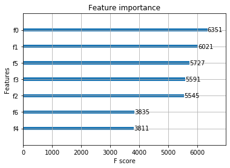

```python
xgb.plot_importance(bst) # feature immportance
```

```python
# !pip install graphviz
```

```python
xgb.to_graphviz(bst, num_trees=2) # second tree. Change this number to display the corresponding tree.
```

[figure not shown]